# Data Visualization in R

# Creating a Bar Plot

Bar plots are used to display numeric values for different categories. Although they appears similar to Histograms, these plots are very different: bar plots are used for categorical x values, bars should be spaced and the weight of the bar has no meaning while histograms are used for continuous x values, bars (that are called *bins*) must not be spaced and the weight of bins depends on data.

To avoid confusion between bar plots and histograms, some authors suggest to build bars horizontally.

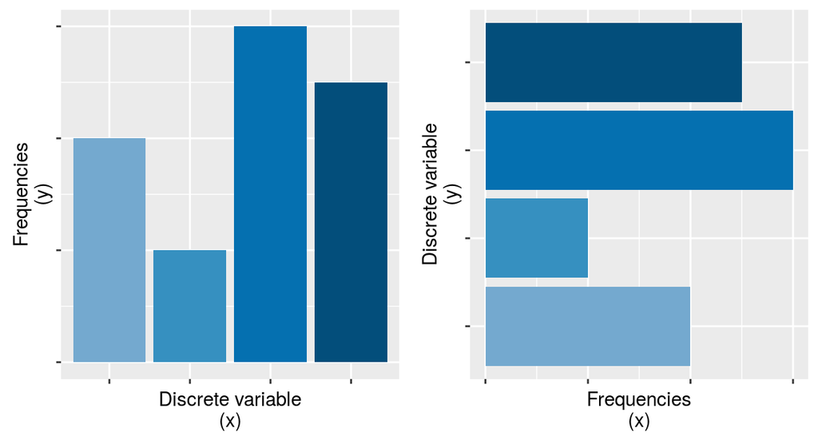

This chapter presents how to build bar plots and introduces other basic concepts of `ggplot2` graphics: `stat`.

# The first bar plot

As seen in the previous chapter, chicks receive one of four diets (see `ChickWeight` data set). A graphical summary about how chicks receive each diet can be obtained.

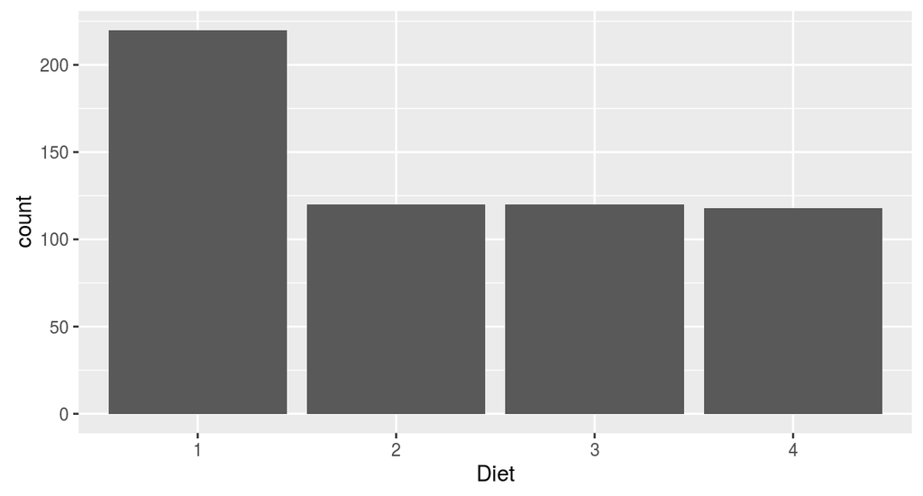

```r
ggplot(data=ChickWeight, mapping=aes(x=Diet)) + geom_bar()
```

If you prefer horizontal bars, just flip the plot with `coord_flip()`.

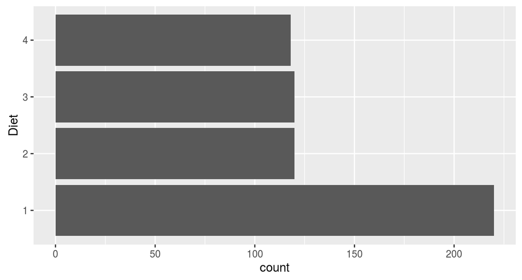

```r
ggplot(data=ChickWeight, mapping=aes(x=Diet)) + geom_bar() + coord_flip()
```

Another way to distinguish bar plots and histograms are tiny bars, to increase the space among bars.

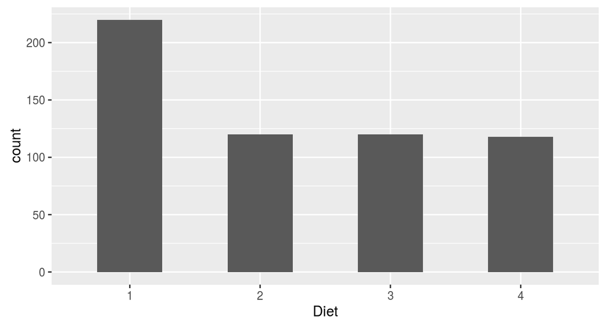

```r
ggplot(data=ChickWeight, mapping=aes(x=Diet)) + geom_bar(width=0.5)
```